# R Notebook

# Pakiety

```r
library(readxl)
```

# Modele nieliniowe

## Funkcja Cobba-Douglas’a

Funkcja zakłada zależność między Produkcją (P), a nakładami Kapitału (K) oraz nakładami Pracy (L).

$$P = \gamma K^\alpha L^\beta\epsilon$$

1. standardowe podejście do tego problemu polega na zlinearyzowaniu czyli doprowadzeniu danego równania do postaci liniowej.

$$\log(P) = \log(\gamma K^\alpha L^\beta)$$

$$\log(P) = \log(\gamma) + \log(K^\alpha) + \log(L^\beta)$$

$$\log(P) = \log(\gamma) + \alpha\log(K) + \beta\log(L)$$

```r
excel_sheets("../data-raw/regresja-ekonometria.xlsx")
```

```
[1] "reg1-krok"         "nielin-hiperbola"  "nielin-cd"         "nielin-tornquist1" "nielin-tornquist2" "logistyczna"
```

```r
dane_cd <- read_excel("../data-raw/regresja-ekonometria.xlsx", sheet = "nielin-cd")
dane_cd
```

| t | P | K | L |
| --- | --- | --- | --- |
| 1 | 864.0 | 13.5 | 359 |
| 2 | 1081.2 | 17.4 | 453 |
| 3 | 1092.8 | 18.7 | 431 |
| 4 | 1194.1 | 23.3 | 423 |
| 5 | 1225.6 | 24.4 | 424 |
| 6 | 1284.6 | 24.2 | 471 |
| 7 | 1409.7 | 28.6 | 486 |
| 8 | 1502.7 | 31.2 | 511 |
| 9 | 1597.4 | 34.1 | 535 |
| 10 | 1634.8 | 33.2 | 574 |

[output cut: 5 more lines]

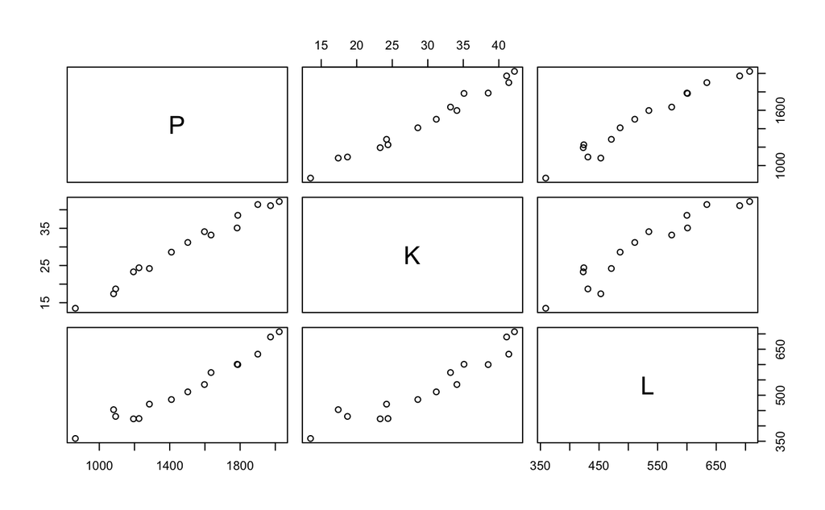

```r
plot(dane_cd[,-1])
```

Szacujemy parametry modelu zlinearyzowanego wykorzystując funkcję `lm`.

```r
model1 <- lm(formula = log(P) ~ log(K) + log(L), data = dane_cd)
summary(model1)
```

```
Call:
lm(formula = log(P) ~ log(K) + log(L), data = dane_cd)

Residuals:
      Min        1Q    Median        3Q       Max
-0.005986 -0.004164 -0.002892 -0.000557  0.034352

Coefficients:
            Estimate Std. Error t value Pr(>|t|)
(Intercept)  2.59256    0.17568   14.76 4.68e-09 ***
log(K)       0.45207    0.02223   20.33 1.15e-10 ***
log(L)       0.50802    0.03883   13.08 1.84e-08 ***
---
Signif. codes:  0 ‘***’ 0.001 ‘**’ 0.01 ‘*’ 0.05 ‘.’ 0.1 ‘ ’ 1

Residual standard error: 0.01064 on 12 degrees of freedom
Multiple R-squared:  0.9985,    Adjusted R-squared:  0.9982
F-statistic:  3993 on 2 and 12 DF,  p-value: < 2.2e-16
```

$$\log(P) = 2.59256 + 0.45207*\log(K) + 0.50802*\log(L)$$

```r
exp(2.59256)
```

```
[1] 13.36394
```

$$P = 13.36394 * K^{0.45207} * L^{0.50802}$$

2. zastosowanie odpowiednich narzędzi (aparatu matematycznego) do rozwiązania tego typu równania bez konieczności stosowania punktu 1.

NLS – non-linear least squares czyli nieliniowa metoda najmniejszych kwadratów

```r
model1_nls <- nls(formula = P ~ gamma*K^alpha*L^beta,
                  data = dane_cd,
                  start = c(gamma = 1, alpha = 0.5, beta = 0.5))
summary(model1_nls)
```

```
Formula: P ~ gamma * K^alpha * L^beta

Parameters:
      Estimate Std. Error t value Pr(>|t|)
gamma 13.48267    2.78998   4.833  0.00041 ***
alpha  0.45034    0.03063  14.702 4.89e-09 ***
beta   0.50756    0.04774  10.631 1.84e-07 ***
---
Signif. codes:  0 ‘***’ 0.001 ‘**’ 0.01 ‘*’ 0.05 ‘.’ 0.1 ‘ ’ 1

Residual standard error: 18.53 on 12 degrees of freedom

Number of iterations to convergence: 7
Achieved convergence tolerance: 9.366e-07
```

Strategia z modelami nieliniowymi jest następująca:

1. jeżeli możemy funkcję zlinearyzować to należy to spróbować zrobić aby dostać oszacowania (punkty) startowe do funkcji nieliniowych

```r
parametry <- as.numeric(coef(model1))
```

2. uzyć wartości oszacowanych parametrów z punktu 1 jako start do funkcji nieliniowej

```r
model1_nls <- nls(formula = P ~ gamma*K^alpha*L^beta,
                  data = dane_cd,
                  start = c(gamma = exp(parametry[1]),
                            alpha = parametry[2],
                            beta = parametry[3]))
summary(model1_nls)
```

```
Formula: P ~ gamma * K^alpha * L^beta

Parameters:
      Estimate Std. Error t value Pr(>|t|)
gamma 13.48267    2.78998   4.833  0.00041 ***
alpha  0.45034    0.03063  14.702 4.89e-09 ***
beta   0.50756    0.04774  10.631 1.84e-07 ***
---
Signif. codes:  0 ‘***’ 0.001 ‘**’ 0.01 ‘*’ 0.05 ‘.’ 0.1 ‘ ’ 1

Residual standard error: 18.53 on 12 degrees of freedom

Number of iterations to convergence: 2
Achieved convergence tolerance: 4.301e-07
```

Kolejny element strategii z modelami nieliniowymi jest zastosowanie róznych punktów startowych aby sprawdzić czy otrzymane wyniki są faktycznie najlepsze czyli osiągnięto minimin/maximum globalne, a nie lokalne.

# Funkcja Tornquista I

```r
torq1 <- read_excel("../data-raw/regresja-ekonometria.xlsx", sheet = "nielin-tornquist1")
torq1
```

| Y | X |
| --- | --- |
| 75 | 1.0 |
| 109 | 1.5 |
| 121 | 2.5 |
| 191 | 5.0 |
| 184 | 6.0 |
| 47 | 0.5 |
| 65 | 0.4 |
| 140 | 3.0 |
| 153 | 3.6 |
| 87 | 1.3 |

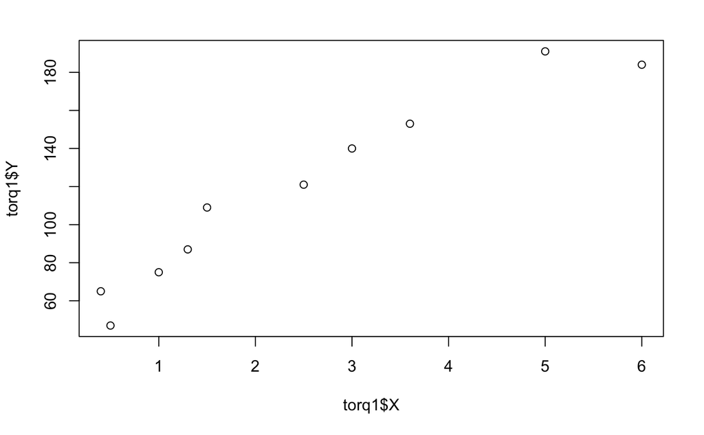

```r
plot(torq1$X, torq1$Y)
```

$$Y = \frac{\alpha X}{X + \beta}$$

Chcemy doporowadzić tę funkcję do postaci zlinearyzowanej

$$Y^{-1} = \left( \frac{\alpha X}{X + \beta}\right)^{-1}$$

$$\frac{1}{Y} = \frac{X+\beta}{\alpha X}$$

$$\frac{1}{Y} = \frac{X}{\alpha X} + \frac{\beta}{\alpha X}$$

$$\frac{1}{Y} = \frac{1}{\alpha} + \frac{\beta}{\alpha}\frac{1}{X}$$

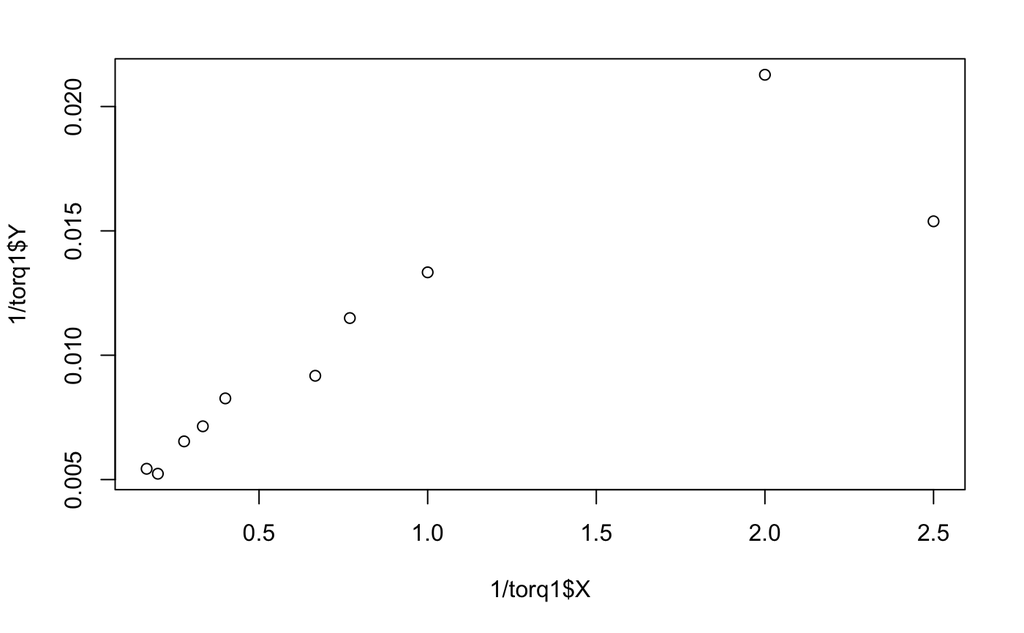

```r
plot(1/torq1$X, 1/torq1$Y)
```

Szacujemy parametry modelu Tornquist’a I wykorzystując postać zlinearyzowaną

```r
model_tornq_lin <- lm(formula = I(1/Y) ~ I(1/X), data = torq1)
summary(model_tornq_lin)
```

```
Call:
lm(formula = I(1/Y) ~ I(1/X), data = torq1)

Residuals:
       Min         1Q     Median         3Q        Max
-0.0044239 -0.0009987 -0.0002863  0.0012366  0.0043090

Coefficients:
            Estimate Std. Error t value Pr(>|t|)
(Intercept) 0.005604   0.001158   4.840 0.001288 **
I(1/X)      0.005682   0.001027   5.531 0.000553 ***
---
Signif. codes:  0 ‘***’ 0.001 ‘**’ 0.01 ‘*’ 0.05 ‘.’ 0.1 ‘ ’ 1

Residual standard error: 0.002472 on 8 degrees of freedom
Multiple R-squared:  0.7927,    Adjusted R-squared:  0.7668
F-statistic: 30.59 on 1 and 8 DF,  p-value: 0.0005535
```

$$\frac{1}{Y} = 0.005604 + 0.005682\frac{1}{X}$$

Wracamy do oryginalnych wartości

```r
alpha <- 1/0.005604
alpha
```

```
[1] 178.444
```

$$\frac{\beta}{\alpha} = 0.005682$$

```r
beta <- alpha*0.005682
beta
```

```
[1] 1.013919
```

Spróbujmy to samo zrobić ale z wykorzystaniem funkcji nls

```r
model_tornq <- nls(formula = Y ~ (alpha*X) / (X + beta),
                   data = torq1,
                   start = c(alpha = 1, beta = 1))
summary(model_tornq)
```

```
Formula: Y ~ (alpha * X)/(X + beta)

Parameters:
      Estimate Std. Error t value Pr(>|t|)
alpha 253.3481    24.9746  10.144 7.63e-06 ***
beta    2.2123     0.5054   4.377  0.00236 **
---
Signif. codes:  0 ‘***’ 0.001 ‘**’ 0.01 ‘*’ 0.05 ‘.’ 0.1 ‘ ’ 1

Residual standard error: 12.54 on 8 degrees of freedom

Number of iterations to convergence: 14
Achieved convergence tolerance: 3.873e-06
```

```r
model_tornq2 <- nls(formula = Y ~ (alpha*X) / (X + beta),
                   data = torq1,
                   start = c(alpha = alpha, beta = beta))
summary(model_tornq2)
```

```
Formula: Y ~ (alpha * X)/(X + beta)

Parameters:
      Estimate Std. Error t value Pr(>|t|)
alpha 253.3482    24.9746  10.144 7.63e-06 ***
beta    2.2123     0.5054   4.377  0.00236 **
---
Signif. codes:  0 ‘***’ 0.001 ‘**’ 0.01 ‘*’ 0.05 ‘.’ 0.1 ‘ ’ 1

Residual standard error: 12.54 on 8 degrees of freedom

Number of iterations to convergence: 7
Achieved convergence tolerance: 2.064e-06
```

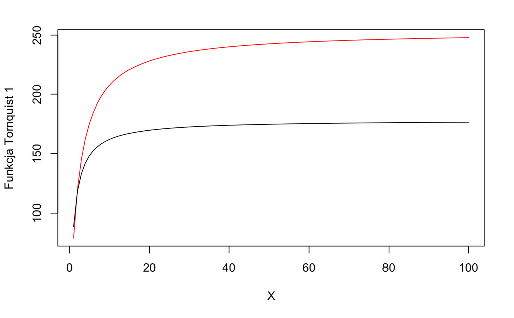

```r
curve(253.3482*x/(x + 2.2123), from = 1, to = 100, xlab = "X", y = "Funkcja Tornquist 1", col = "red")
curve(alpha*x/(x + beta), from = 1, to = 100, xlab = "X", y = "Funkcja Tornquist 1", add = T, col = "black")
```

## Funkcja logistyczna

```r
dane_logistyczna <- read_excel("../data-raw/regresja-ekonometria.xlsx", sheet = "logistyczna")
dane_logistyczna
```

| Rok | t | Y |
| --- | --- | --- |
| 1987 | 1 | 1 |
| 1988 | 2 | 4 |
| 1989 | 3 | 9 |
| 1990 | 4 | 21 |
| 1991 | 5 | 46 |
| 1992 | 6 | 92 |
| 1993 | 7 | 156 |
| 1994 | 8 | 218 |
| 1995 | 9 | 260 |
| 1996 | 10 | 283 |

[output cut: 3 more lines]

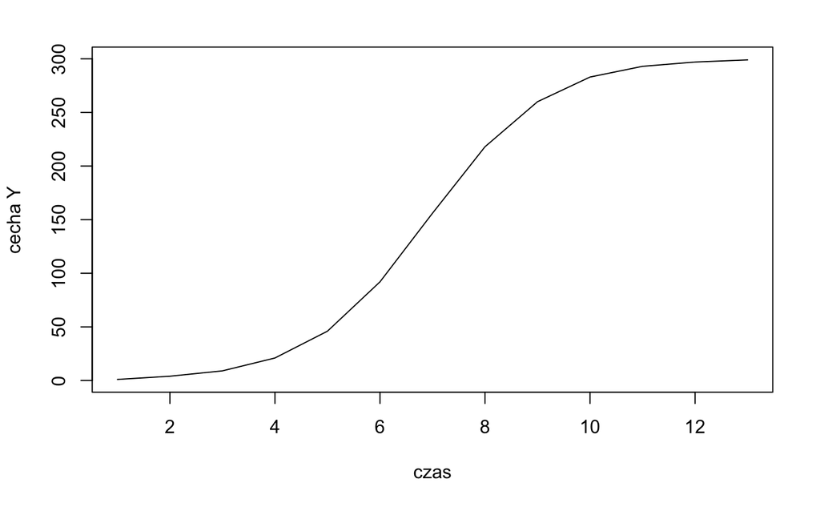

```r
plot(dane_logistyczna$t, dane_logistyczna$Y, type = "l", xlab = "czas", ylab = "cecha Y")
```

Model oparty na funkcji logistycznej możemy oszacować w sposób prosty wyłączenie z funkcją nls. Nie możemy doprowadzić tej funkcji do postaci zlinearyzowanej.

W R mamy do tego specjalną funkcję, która nazywa się SSlogis, która przyjmuje następujące argumenty

```
SSlogis(X, A, m, s)
```

zgodnie z następującym wzorem

$$Y = \frac{A}{1 + e^{(m - X)/s}}$$

```r
## punkty statowe
getInitial(Y ~ SSlogis(t, A, x, s), data = dane_logistyczna)
```

```
         A          x          s
300.444517   6.913030   1.118906
```

```r
## oszacowane parametry
model_logis <- nls(Y ~ SSlogis(t, A, x, s), data = dane_logistyczna)
summary(model_logis)
```

```
Formula: Y ~ SSlogis(t, A, x, s)

Parameters:
   Estimate Std. Error t value Pr(>|t|)
A 3.004e+02  1.825e-01    1646   <2e-16 ***
x 6.913e+00  3.252e-03    2126   <2e-16 ***
s 1.119e+00  2.709e-03     413   <2e-16 ***
---
Signif. codes:  0 ‘***’ 0.001 ‘**’ 0.01 ‘*’ 0.05 ‘.’ 0.1 ‘ ’ 1

Residual standard error: 0.2947 on 10 degrees of freedom

Number of iterations to convergence: 0
Achieved convergence tolerance: 1.629e-06
```

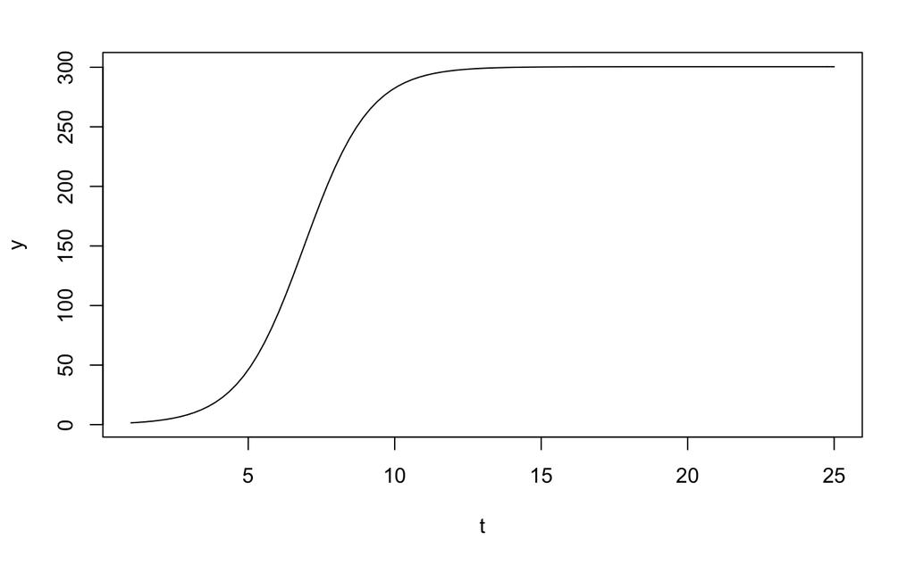

```r
params <- coef(model_logis)
curve(params[1] / (1 + exp( (params[2] - x)/params[3])), from = 1, to  = 25, xlab = "t", y = "y")
```

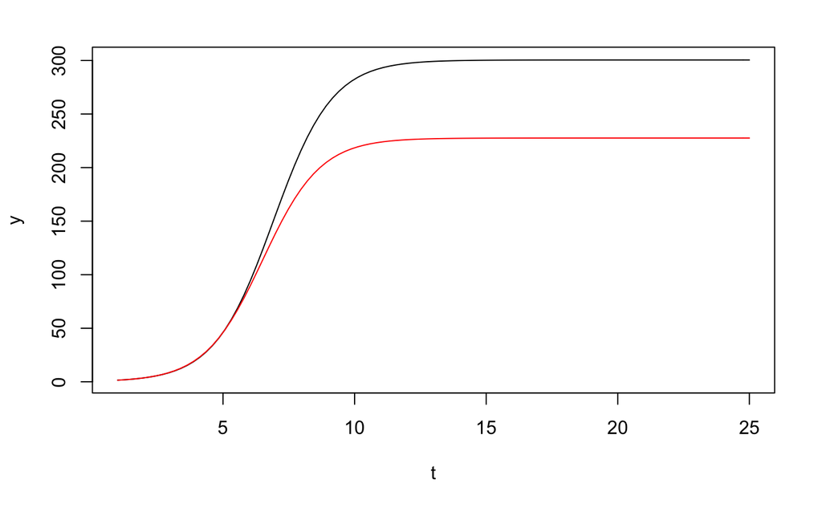

```r
model_logis2 <- nls(Y ~ SSlogis(t, A, x, s), data = dane_logistyczna[dane_logistyczna$t <= 5, ])

params <- coef(model_logis)
params2 <- coef(model_logis2)
curve(params[1] / (1 + exp( (params[2] - x)/params[3])), from = 1, to  = 25, xlab = "t", y = "y")
curve(params2[1] / (1 + exp( (params2[2] - x)/params2[3])), from = 1, to  = 25, xlab = "t", y = "y", add = T, col = "red")
```

## tornquist 2

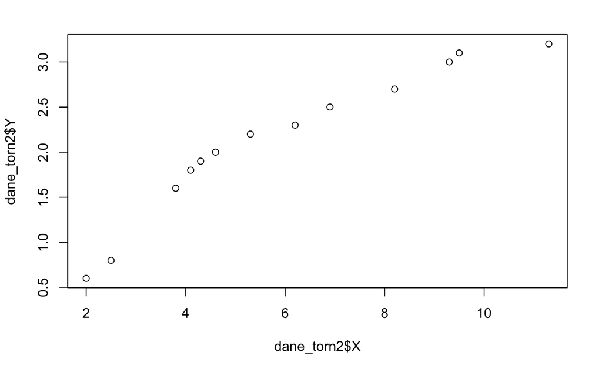

```r
dane_torn2 <- read_excel("../data-raw/regresja-ekonometria.xlsx", sheet = "nielin-tornquist2")
plot(dane_torn2$X, dane_torn2$Y)
```

```r
model_tornq_model2 <- nls(formula = Y ~ alpha*(X - gamma)/(X + beta),
                          data = dane_torn2,
                          start = c(alpha=0.5, gamma = 0.5, beta = 0.5))
summary(model_tornq_model2)
```

```
Formula: Y ~ alpha * (X - gamma)/(X + beta)

Parameters:
      Estimate Std. Error t value Pr(>|t|)
alpha   4.6596     0.2566  18.158 5.51e-09 ***
gamma   1.4006     0.1252  11.183 5.65e-07 ***
beta    3.0973     0.7544   4.106  0.00213 **
---
Signif. codes:  0 ‘***’ 0.001 ‘**’ 0.01 ‘*’ 0.05 ‘.’ 0.1 ‘ ’ 1

Residual standard error: 0.08229 on 10 degrees of freedom

Number of iterations to convergence: 8
Achieved convergence tolerance: 1.925e-06
```

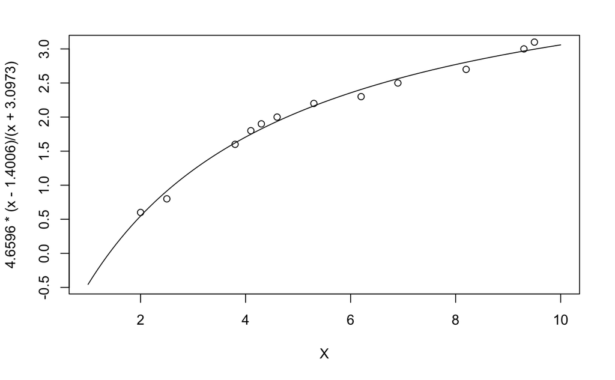

```r
curve(4.6596*(x - 1.4006)/(x + 3.0973), from = 1, to = 10, xlab = "X")
points(dane_torn2$X, dane_torn2$Y)
```